# Portfolio Analysis by Onyeka Okonkwo

#BUSINESS INFO AND PROBLEM Data is for a loan company serving the under-served market. The company provides credit facilities to customers for uses ranging from Business, Education, Groceries and Personal effects.

#TASK 1. Descriptive analytics of the data 2. PAR Analysis showing evolution & recommendations, for this analysis please use PAR7, PAR15, PAR30 and PAR60

#IMPORT DATA

Import, Load libraries and View data

```r
library(readr)
library(dplyr)
library(lubridate)
df <- read_csv("C:/Users/onokonkwo/Desktop/Credit Case Study/data_case_study.csv")
View(df)
```

Data structure

```r
str(df)
```

```
spec_tbl_df [350,844 x 18] (S3: spec_tbl_df/tbl_df/tbl/data.frame)
 $ date             : chr [1:350844] "15/03/2021" "15/03/2021" "15/03/2021" "15/03/2021" ...
 $ user_id          : num [1:350844] 1483192 1173117 1352358 1290014 1504236 ...
 $ loan_id          : chr [1:350844] "e1f35912-301a-4e7f-b769-4c0ae4482963" "d465a501-ed4b-432d-b7b3-b8c39da25fbe" "3cc12530-9046-4b87-b327-1757cb95b361" "0c433515-d8e1-4286-9509-8ebfa974e9f9" ...
 $ principal        : num [1:350844] 14286 38095 11905 11905 11905 ...
 $ balance          : num [1:350844] 14286 38095 11905 11905 11905 ...
 $ repaid           : num [1:350844] 0 0 0 0 0 ...
 $ days_late        : num [1:350844] NA NA NA NA NA NA NA NA NA 20 ...
 $ loan_status      : chr [1:350844] "On Time" "On Time" "On Time" "On Time" ...
 $ product_type     : chr [1:350844] "SHORT" "SHORT" "SHORT" "SHORT" ...
 $ reason           : chr [1:350844] "Business" "Business" "Business" "Medical fees" ...
 $ approval_date    : chr [1:350844] "10/03/2021" "10/03/2021" "10/03/2021" "10/03/2021" ...
 $ last_payment_date: chr [1:350844] "25/03/2021" "25/03/2021" "09/04/2021" "09/04/2021" ...
 $ default_date     : chr [1:350844] "23/06/2021" "23/06/2021" "08/07/2021" "08/07/2021" ...
 $ bank             : chr [1:350844] "G" "G" "O" "C" ...
 $ gender           : chr [1:350844] "male" "male" "female" "male" ...
 $ state            : chr [1:350844] "Y25" "Y25" "BY" "D4" ...
 $ date_of_birth    : chr [1:350844] "23/07/1983" "25/11/1972" "06/05/1987" "19/01/1992" ...
 $ employment_status: chr [1:350844] "SELF-EMPLOYED" "SELF-EMPLOYED" "SELF-EMPLOYED" "SELF-EMPLOYED" ...
 - attr(*, "spec")=
  .. cols(
  ..   date = col_character(),
  ..   user_id = col_double(),
  ..   loan_id = col_character(),
  ..   principal = col_number(),
  ..   balance = col_number(),
  ..   repaid = col_double(),
  ..   days_late = col_double(),
  ..   loan_status = col_character(),
  ..   product_type = col_character(),
  ..   reason = col_character(),
  ..   approval_date = col_character(),
  ..   last_payment_date = col_character(),
  ..   default_date = col_character(),
  ..   bank = col_character(),
  ..   gender = col_character(),
  ..   state = col_character(),
  ..   date_of_birth = col_character(),
  ..   employment_status = col_character()
  .. )
 - attr(*, "problems")=<externalptr>
```

#DATA CLEANING AND PREP

###Change class of variables

rounding numeric values to 2 decimal

```r
df[,4:6] <- round(df[,4:6], digits = 2)
```

Characters to Factors

```r
df[,8:10] <- lapply(df[,8:10], as.factor)
df$gender <- as.factor(df$gender)
df$employment_status <- as.factor(df$employment_status)
```

Character to Dates

```r
df$date_of_birth <- dmy(df$date_of_birth)
df$approval_date <- dmy(df$approval_date)
```

```r
df$date <- dmy(df$date)
df$last_payment_date <- dmy(df$last_payment_date)
df$default_date <- dmy(df$default_date)
```

Arrange Date column in chronological order

```r
df %>% arrange(date)
```

| date | user_id | loan_id | principal | balance | repaid | days_late | loan_status | product_type | reason | approval_date | last_payment_date | default_date | bank | gender | state | date_of_birth | employment_status |
| --- | --- | --- | --- | --- | --- | --- | --- | --- | --- | --- | --- | --- | --- | --- | --- | --- | --- |
| 2021-03-15 | 1483192 | e1f35912-301a-4e7f-b769-4c0ae4482963 | 14285.7 | 14285.7 | 0.00 | NA | On Time | SHORT | Business | 2021-03-10 | 2021-03-25 | 2021-06-23 | G | male | Y25 | 1983-07-23 | SELF-EMPLOYED |
| 2021-03-15 | 1173117 | d465a501-ed4b-432d-b7b3-b8c39da25fbe | 38095.2 | 38095.2 | 0.00 | NA | On Time | SHORT | Business | 2021-03-10 | 2021-03-25 | 2021-06-23 | G | male | Y25 | 1972-11-25 | SELF-EMPLOYED |
| 2021-03-15 | 1352358 | 3cc12530-9046-4b87-b327-1757cb95b361 | 11904.8 | 11904.8 | 0.00 | NA | On Time | SHORT | Business | 2021-03-10 | 2021-04-09 | 2021-07-08 | O | female | BY | 1987-05-06 | SELF-EMPLOYED |
| 2021-03-15 | 1290014 | 0c433515-d8e1-4286-9509-8ebfa974e9f9 | 11904.8 | 11904.8 | 0.00 | NA | On Time | SHORT | Medical fees | 2021-03-10 | 2021-04-09 | 2021-07-08 | C | male | D4 | 1992-01-19 | SELF-EMPLOYED |
| 2021-03-15 | 1504236 | 4a498d09-e54c-4d4b-95f5-ba3ed007d1aa | 11904.8 | 11904.8 | 0.00 | NA | On Time | SHORT | Business | 2021-03-10 | 2021-03-25 | 2021-06-23 | L | female | Y25 | 1997-12-16 | SELF-EMPLOYED |
| 2021-03-15 | 1099554 | f6426a8c-201d-424d-ac08-ea06c49d8f51 | 14285.7 | 14285.7 | 0.00 | NA | On Time | SHORT | Business | 2021-03-10 | 2021-03-25 | 2021-06-23 | O | male | Y25 | 1998-12-25 | SELF-EMPLOYED |
| 2021-03-15 | 1488311 | 5b485d9c-930f-4b82-9c38-1f96787984aa | 7142.9 | 7142.9 | 0.00 | NA | On Time | SCALING | Transportation/Travel | 2021-03-10 | 2021-03-25 | 2021-06-23 | P | female | N14 | 1989-11-09 | EMPLOYED |
| 2021-03-15 | 348033 | 15832e96-6733-47c8-baf9-1ab364a43466 | 52381.0 | 52381.0 | 0.00 | NA | On Time | SHORT | Salary advance | 2021-03-10 | 2021-04-09 | 2021-07-08 | D | female | B2 | 1986-03-06 | SELF-EMPLOYED |
| 2021-03-15 | 409808 | 476ff167-7a7a-4816-920e-e707c9c81b08 | 71428.6 | 71428.6 | 0.00 | NA | On Time | SHORT | Personal/Confidential | 2021-03-03 | 2021-04-02 | 2021-07-01 | G | male | GT | 1977-09-23 | SELF-EMPLOYED |
| 2021-03-15 | 1243070 | 2f844e03-b60c-466b-802d-dd95683cc68c | 64285.7 | 64285.7 | 11904.76 | 20 | Late | SHORT | Business | 2021-02-08 | 2021-02-23 | 2021-05-24 | D | male | Y25 | 1980-06-16 | SELF-EMPLOYED |

[output cut: 990 more lines]

Search for missing values, identifies how many and what columns they’re in

```r
sum(is.na(df))
```

```
[1] 217878
```

```r
names(df[, !complete.cases(t(df))])
```

```
[1] "balance"       "days_late"     "date_of_birth"
```

Summary of Data

```r
summary(df)
```

```
      date               user_id          loan_id            principal         balance
 Min.   :2021-03-15   Min.   :     26   Length:350844      Min.   :  7143   Min.   :     1.2
 1st Qu.:2021-03-29   1st Qu.: 517404   Class :character   1st Qu.: 11905   1st Qu.: 11904.8
 Median :2021-04-12   Median :1187943   Mode  :character   Median : 23810   Median : 23809.5
 Mean   :2021-04-08   Mean   : 992014                      Mean   : 33211   Mean   : 32530.2
 3rd Qu.:2021-04-26   3rd Qu.:1433756                      3rd Qu.: 52381   3rd Qu.: 52381.0
 Max.   :2021-05-03   Max.   :1627539                      Max.   :273810   Max.   :273809.5
                                                                            NA's   :144
     repaid         days_late       loan_status      product_type                      reason
 Min.   :     0   Min.   : 1.0     Late   :133118   LONG   :  2596   Business             :150619
 1st Qu.:     0   1st Qu.:14.0     On Time:217726   SCALING: 67164   Household Goods      : 39320
 Median :     0   Median :33.0                      SHORT  :281084   Medical fees         : 34397
 Mean   :  1591   Mean   :37.2                                       Personal/Confidential: 34382
 3rd Qu.:     0   3rd Qu.:59.0                                       Emergency            : 29284
 Max.   :250000   Max.   :90.0                                       Education            : 18162
                  NA's   :217726                                     (Other)              : 44680
 approval_date        last_payment_date     default_date            bank              gender
 Min.   :2020-10-30   Min.   :2020-12-16   Min.   :2021-03-16   Length:350844      female:110833
 1st Qu.:2021-02-22   1st Qu.:2021-03-18   1st Qu.:2021-06-16   Class :character   male  :240011
 Median :2021-03-15   Median :2021-04-09   Median :2021-07-08   Mode  :character
 Mean   :2021-03-09   Mean   :2021-04-03   Mean   :2021-07-02
 3rd Qu.:2021-04-02   3rd Qu.:2021-04-29   3rd Qu.:2021-07-28
 Max.   :2021-05-03   Max.   :2021-12-18   Max.   :2022-03-18

    state           date_of_birth            employment_status
 Length:350844      Min.   :1970-01-01   EMPLOYED     :162737
 Class :character   1st Qu.:1981-03-03   SELF-EMPLOYED:188107
 Mode  :character   Median :1987-02-14
                    Mean   :1986-07-04
                    3rd Qu.:1992-05-12
                    Max.   :2003-04-14
                    NA's   :8
```

###NOTES

1. Data length is 350844 rows and 18 columns (created additional for Age)
2. Date ranges from 15/3/2021 to 3/05/2021
3. Highest amount disbursed was N273,810 and lowest was N7,143
4. 37.9% of customers were late on payment
5. Company has 3 product category - Short, Scaling and Long. Majority of customers (80%) took Short product. This increases liquidity and availability of working capital for the company if payment is timely.
6. 42.9% required loan for business, while between 5% and 11% needed a loan for Household goods, Personal, Emergency, Education and Medical Fees.
7. Gender of customers was 68% male and 31% female.
8. 53.6% were self-employed and 46.3% were employed.
9. Customers age range from 18 to 51.

Check unique values in loan id, user id, state and bank

```r
length(unique(df$user_id))
```

```
[1] 59988
```

```r
length(unique(df$loan_id))
```

```
[1] 108752
```

```r
length(unique(df$state))
```

```
[1] 37
```

```r
length(unique(df$bank))
```

```
[1] 19
```

###NOTES:

#TREATMENT OF MISSING VALUES (NA)

Date of Birth (8) impute with median value

```r
df$date_of_birth[is.na(df$date_of_birth)] <- median(df$date_of_birth, na.rm = TRUE)
```

User ID 439447 (1258b7a2-6a23-4146-aed4-e0117ea29234) has no Date of Birth recorded.

Days Late (217726) Calculate for values i.e. if last payment date is less than date, then calculate days late, otherwise return value as 0.

```r
df$days_late <- ifelse((df$last_payment_date < df$date), (df$date - df$last_payment_date), 0)
```

Balance (144) - calculate field and fill. We’ll run multiple test conditions for this.

###Test 1 (144 NA) Replace with corresponding principal value when repayment is 0

```r
df$balance <- ifelse(df$repaid==0 & is.na(df$balance), df$principal, df$balance)
```

###Test 2 (135 NA) Group by User ID and Loan ID, then fill NA in balance with Principal if the repaid value is same as above

```r
df2 <- df%>%
  group_by(user_id, loan_id) %>%
  mutate(balance = ifelse(is.na(balance) & repaid == lag(repaid, n=1), principal, balance))
```

###(contd. Test 2 - 76 NA) Group by User ID and Loan ID, then fill NA in balance with Principal if the repaid value is same as below

```r
df3 <- df2%>%
  group_by(user_id, loan_id) %>%
  mutate(balance = ifelse(is.na(balance) & repaid == lead(repaid, n=1), principal, balance))
```

###Test 3 (52 NA) Group by User ID and Loan ID, then fill NA in Balance with 0 if customer paid more than existing loan balance, otherwise leave value as NA.

```r
df4 <- df3 %>%
  group_by(user_id, loan_id) %>%
  mutate(balance = ifelse(is.na(balance) & (repaid - lag(repaid, n=1))>lag(balance, n=1), 0, balance))
```

###Test 4 (15 NA) Group by user Id and Loan ID, if the repaid value is greater than existing loan balance, then fill with 0, otherwise leave as NA

```r
df5 <- df4%>%
  group_by(user_id, loan_id) %>%
  mutate(balance = ifelse(is.na(balance) & repaid > lag(balance, n=1), 0, balance))
```

This code seems similar to the previous chunk so no NAs were affected. May be okay to omit, but safe to keep it.

###Test 5 (15 NA) Return 0 if repaid value is greater than loan principal

```r
df6 <- df5%>%
  group_by(user_id, loan_id) %>%
  mutate(balance = ifelse(is.na(balance) & repaid > principal, 0, balance))
```

###check if there’s any NA left

```r
sum(is.na(df6))
```

```
[1] 0
```

```r
names(df6[, !complete.cases(t(df6))])
```

```
character(0)
```

All cleared!! Now we can move forward.

Create New column for Age of Customers using Approval Date and DOB

```r
library(dplyr)
calc_age <- function(birthDate, refDate = Sys.Date(), unit = "year") {

  require(lubridate)

  if(grepl(x = unit, pattern = "year")) {
    as.period(interval(birthDate, refDate), unit = 'year')$year
  } else if(grepl(x = unit, pattern = "month")) {
    as.period(interval(birthDate, refDate), unit = 'month')$month
  } else if(grepl(x = unit, pattern = "week")) {
    floor(as.period(interval(birthDate, refDate), unit = 'day')$day / 7)
  } else if(grepl(x = unit, pattern = "day")) {
    as.period(interval(birthDate, refDate), unit = 'day')$day
  } else {
    print("Argument 'unit' must be one of 'year', 'month', 'week', or 'day'")
    NA
  }

}
df6$Age = calc_age(birthDate = df6$date_of_birth, refDate = df6$approval_date, unit = "year")
```

rename df6

```r
Cleandf <- df6
```

VIEW DATA

```r
View(Cleandf)
```

#DATA VISUALISATION AND EDA

```r
library(ggplot2)
library(DataExplorer)
```

[figure not shown]

```r
p <- ggplot(data = Cleandf, aes(x = gender , y = principal))
print(p)
```

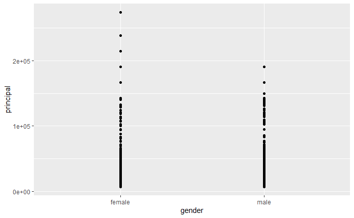

```r
print(p + geom_point())
```

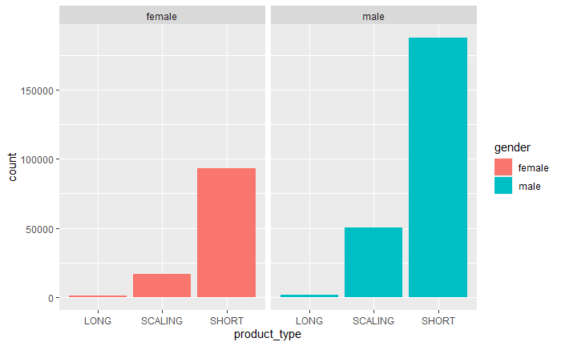

```r
ggplot(group_by(Cleandf, loan_id), aes(x = product_type, fill = gender))+
  geom_bar() +
  facet_wrap(~ gender)
```

Between the 3 product categories for both genders, more customers took Short loans, and men took more loans in general than women.

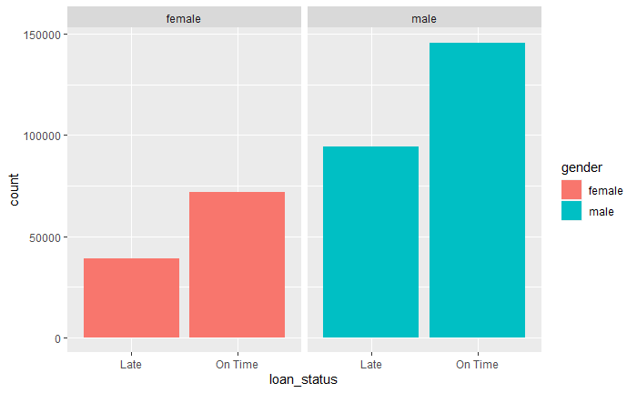

```r
ggplot(data = Cleandf, aes(x = loan_status, fill = gender))+
  geom_bar() +
  facet_wrap(~ gender)
```

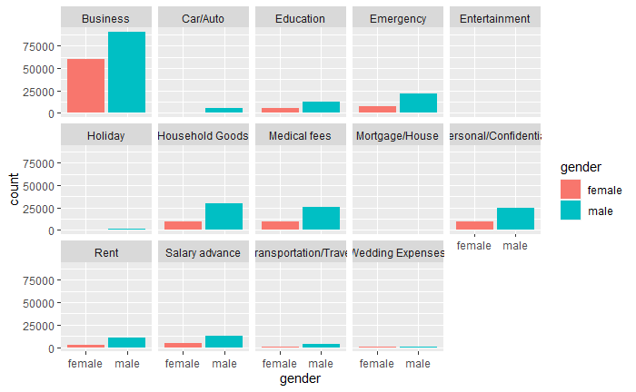

```r
ggplot(group_by(Cleandf, loan_id), aes(x = gender, fill = gender))+
  geom_bar() +
  facet_wrap(~ reason, nrow = 3)
```

Both gender took more business loans, and others in these category topped reasons for loans collected - emergency, household goods, medical fees and person/confidential reasons.

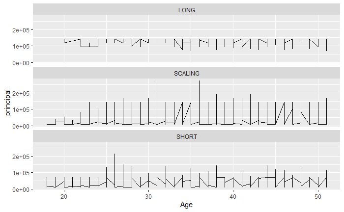

```r
ggplot(group_by(Cleandf, loan_id), aes(x = Age, y = principal))+
  geom_line()+
  facet_wrap(~ product_type, nrow = 3)
```

In scaling category, customers between ages 30 and 40 took the most loans. For short loans ages 25 - 30 took more loans. Collection of long loans are evenly distributed across the age groups.

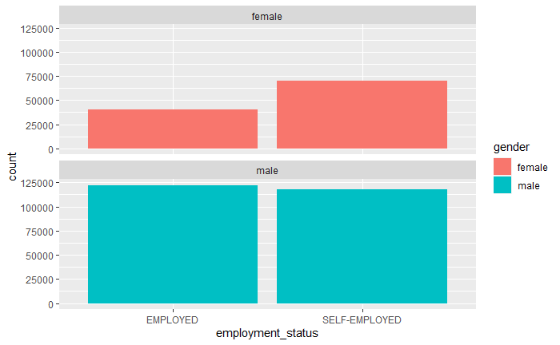

```r
ggplot(group_by(Cleandf, loan_id), aes(employment_status, fill = gender))+
  geom_bar() +
  facet_wrap(~ gender, nrow = 2)
```

Among the customers, there are more self-employed women and more employed men.

```r
create_report(Cleandf)
```

```
processing file: report.rmd
```

[output not shown]

[output cut: 94 more lines]

[output not shown]

```
output file: C:/Users/onokonkwo/Desktop/R code/report.knit.md
```

[output not shown]

```
Output created: report.html
```

```
5 columns ignored with more than 50 categories.
loan_id: 108752 categories
approval_date: 173 categories
last_payment_date: 229 categories
default_date: 229 categories
date_of_birth: 11177 categories
```

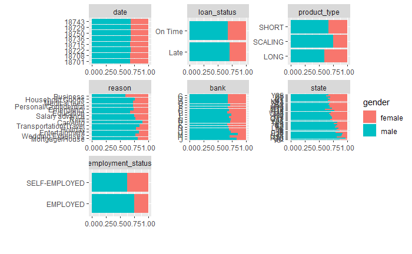

```r
plot_bar(Cleandf, by = "gender")
```

Loan Status - more women paid on time than men. Product Type - men took more scaling loan product, while women took more of Long product. Reason - women took more loans for business and education, and men for car/auto and transport/travel. Employment Status - More self-employed women and employed men.

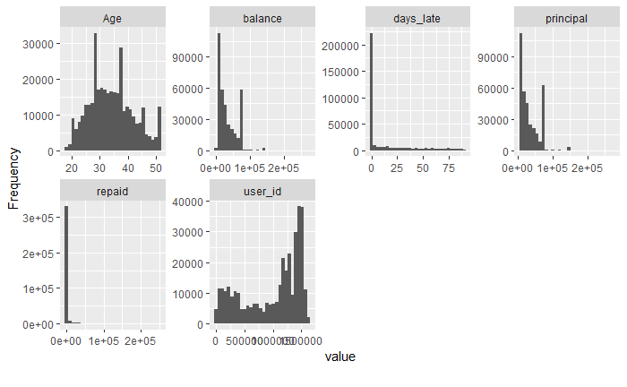

```r
plot_histogram(Cleandf)
```

Age - most customers between 28 and 38

```
5 columns ignored with more than 50 categories.
loan_id: 108752 categories
approval_date: 173 categories
last_payment_date: 229 categories
default_date: 229 categories
date_of_birth: 11177 categories
```

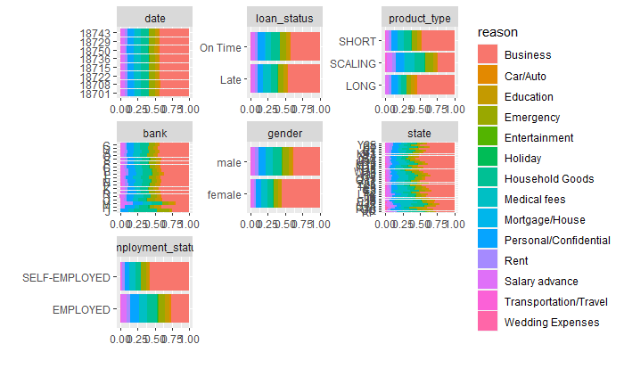

```r
plot_bar(Cleandf, by = "reason")
```

Product type - More long product taken for business reason Employment status - Self-employed customers took more business loans

```
5 columns ignored with more than 50 categories.
loan_id: 108752 categories
approval_date: 173 categories
last_payment_date: 229 categories
default_date: 229 categories
date_of_birth: 11177 categories
```

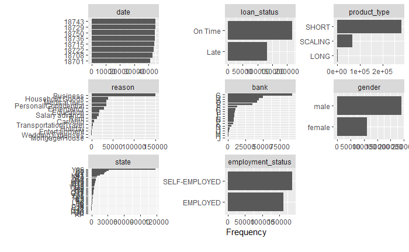

```r
plot_bar(Cleandf)
```

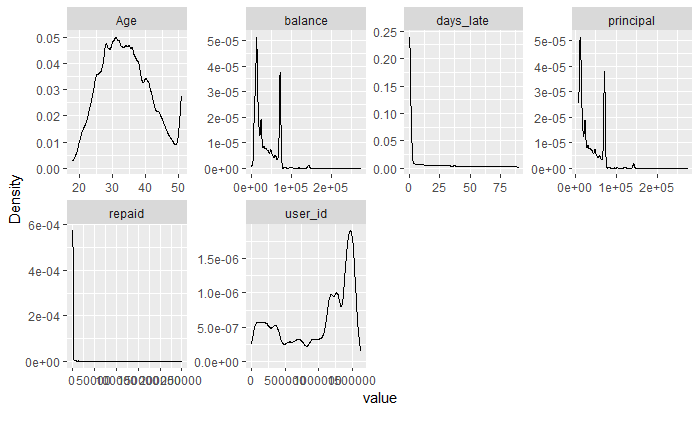

```r
plot_density(Cleandf)
```

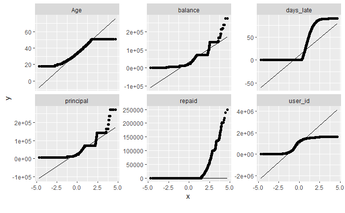

```r
plot_qq(Cleandf)
```

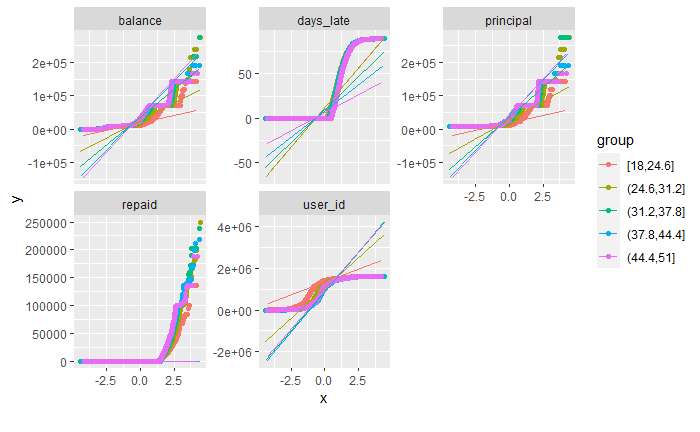

```r
plot_qq(Cleandf, by = "Age")
```

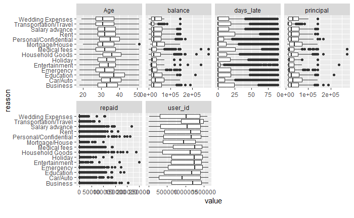

```r
plot_boxplot(Cleandf, by = "reason")
```

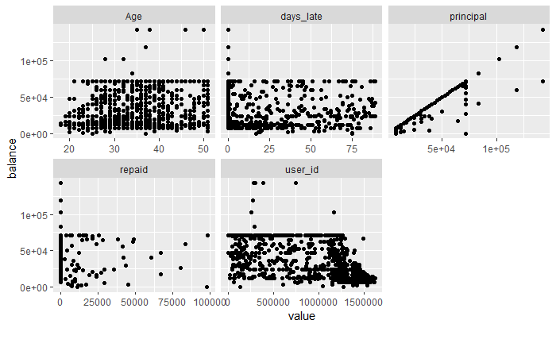

```r
plot_scatterplot(split_columns(Cleandf)$continuous, by = "balance", sampled_rows = 1000L)
```

Save as csv file

```r
write.csv(Cleandf, "CleanCS.csv")
```

```r
df7 <- Cleandf %>%
group_by(date, loan_id)
```

```r
length(unique(df7$balance))
```

```
[1] 3597
```

```r
sum(unique(df7$balance))
```

```
[1] 103659135
```

NOTES

#Portfolio At Risk (PAR) ANALYSIS and EVOLUTION (7, 15, 30, 60)

Portfolio-at-risk (PAR) ratio : Portfolio at risk (X days) / Gross loan portfolio Evolution (Per week?) 15/3, 22/3, 29/3, 5/4, 12/4, 19/4, 26/4, 3/5 (8 weeks in total)

Task - sum by week Group by Date (week) and loan ID

###Wk 1 - 15/3

```r
Wk1 <- Cleandf %>%
  filter(date == "2021/03/15") %>%
  select(date, user_id, loan_id, principal, balance, days_late)%>%
  group_by(date, user_id, loan_id)
```

```r
View(Wk1)
```

GLP of Week 1 - 1,375,404,576

```r
sum(Wk1$balance)
```

```
[1] 1375404576
```

```r
length(unique(Cleandf$user_id))
```

```
[1] 59988
```

EVOLUTION FOR WEEK 1

sum of balance when days late is 7 and above - 27.39%

```r
Par7wk1 <- Wk1 %>%
  filter(days_late > 7)
```

```r
sum(Par7wk1$balance)/1375404576
```

```
[1] 0.273875
```

sum of balance when days late is 15 and above - 23.28%

```r
Par15wk1 <- Wk1 %>%
  filter(days_late > 15)
```

```r
sum(Par15wk1$balance)/1375404576
```

```
[1] 0.2328037
```

sum of balance when days late is 30 and above 17.44%

```r
Par30wk1 <- Wk1 %>%
  filter(days_late > 30)
```

```r
sum(Par30wk1$balance)/1375404576
```

```
[1] 0.1744588
```

sum of balance when days late is 60 and above - 7.86%

```r
Par60wk1 <- Wk1 %>%
  filter(days_late > 60)
```

```r
sum(Par60wk1$balance)/1375404576
```

```
[1] 0.07856392
```

###Wk 2 - 22/3

```r
Wk2 <- Cleandf %>%
  filter(date == "2021/03/22") %>%
  select(date, user_id, loan_id, principal, balance, days_late)%>%
  group_by(date, user_id, loan_id)
```

GLP Wk2 - 1,405,305,146

```r
View(Wk2)
sum(Wk2$balance)
```

```
[1] 1405305146
```

EVOLUTION FOR WEEK 2

sum of balance when days late is 7 and above - 26.26%

```r
Par7wk2 <- Wk2 %>%
  filter(days_late > 7)
```

```r
sum(Par7wk2$balance)/1405305146
```

```
[1] 0.2625645
```

sum of balance when days late is 15 and above - 23.16%

```r
Par15wk2 <- Wk2 %>%
  filter(days_late > 15)
```

```r
sum(Par15wk2$balance)/1405305146
```

```
[1] 0.2316474
```

sum of balance when days late is 30 and above - 17.13%

```r
Par30wk2 <- Wk2 %>%
  filter(days_late > 30)
```

```r
sum(Par30wk2$balance)/1405305146
```

```
[1] 0.1712799
```

sum of balance when days late is 60 and above - 8.19%

```r
Par60wk2 <- Wk2 %>%
  filter(days_late > 60)
```

```r
sum(Par60wk2$balance)/1405305146
```

```
[1] 0.08185723
```

###Wk 3 - 29/3

```r
Wk3 <- Cleandf %>%
  filter(date == "2021/03/29") %>%
  select(date, user_id, loan_id, principal, balance, days_late)%>%
  group_by(date, user_id, loan_id)
```

GLP wk 3 = 1,411,598,292

```r
View(Wk3)
sum(Wk3$balance)
```

```
[1] 1411598292
```

WEEK 3 EVOLUTION

sum of balance when days late is 7 and above - 26.51%

```r
Par7wk3 <- Wk3 %>%
  filter(days_late > 7)
```

```r
sum(Par7wk3$balance)/1411598292
```

```
[1] 0.2650545
```

sum of balance when days late is 15 and above - 23.08%

```r
Par15wk3 <- Wk3 %>%
  filter(days_late > 15)
```

```r
sum(Par15wk3$balance)/1411598292
```

```
[1] 0.2307892
```

sum of balance when days late is 30 and above - 17.52%

```r
Par30wk3 <- Wk3 %>%
  filter(days_late > 30)
```

```r
sum(Par30wk3$balance)/1411598292
```

```
[1] 0.1751651
```

sum of balance when days late is 60 and above - 8.46%

```r
Par60wk3 <- Wk3 %>%
  filter(days_late > 60)
```

```r
sum(Par60wk3$balance)/1411598292
```

```
[1] 0.08464391
```

###Wk 4 - 5/4

```r
Wk4 <- Cleandf %>%
  filter(date == "2021/04/05") %>%
  select(date, user_id, loan_id, principal, balance, days_late)%>%
  group_by(date, user_id, loan_id)
```

GLP = 1,414,476,977

```r
View(Wk4)
sum(Wk4$balance)
```

```
[1] 1414476977
```

WEEK 4 EVOLUTION

sum of balance when days late is 7 and above - 26.40%

```r
Par7wk4 <- Wk4 %>%
  filter(days_late > 7)
```

```r
sum(Par7wk4$balance)/1414476977
```

```
[1] 0.2639984
```

sum of balance when days late is 15 and above - 22.92%

```r
Par15wk4 <- Wk4 %>%
  filter(days_late > 15)
```

```r
sum(Par15wk4$balance)/1414476977
```

```
[1] 0.2292069
```

sum of balance when days late is 30 and above - 17.87%

```r
Par30wk4 <- Wk4 %>%
  filter(days_late > 30)
```

```r
sum(Par30wk4$balance)/1414476977
```

```
[1] 0.1787441
```

sum of balance when days late is 60 and above - 8.18%

```r
Par60wk4 <- Wk4 %>%
  filter(days_late > 60)
```

```r
sum(Par60wk4$balance)/1414476977
```

```
[1] 0.08176224
```

###Wk 5 - 12/4

```r
Wk5 <- Cleandf %>%
  filter(date == "2021/04/12") %>%
  select(date, user_id, loan_id, principal, balance, days_late)%>%
  group_by(date, user_id, loan_id)
```

GLP wk 5 = 1,458,110,474

```r
View(Wk5)
sum(Wk5$balance)
```

```
[1] 1458110474
```

WEEK 5 EVOLUTION

sum of balance when days late is 7 and above - 27.42%

```r
Par7wk5 <- Wk5 %>%
  filter(days_late > 7)
```

```r
sum(Par7wk5$balance)/1458110474
```

```
[1] 0.2742133
```

sum of balance when days late is 15 and above - 22.75%

```r
Par15wk5 <- Wk5 %>%
  filter(days_late > 15)
```

```r
sum(Par15wk5$balance)/1458110474
```

```
[1] 0.2275141
```

sum of balance when days late is 30 and above - 17.63%

```r
Par30wk5 <- Wk5 %>%
  filter(days_late > 30)
```

```r
sum(Par30wk5$balance)/1458110474
```

```
[1] 0.1762583
```

sum of balance when days late is 60 and above - 8.09%

```r
Par60wk5 <- Wk5 %>%
  filter(days_late > 60)
```

```r
sum(Par60wk5$balance)/1458110474
```

```
[1] 0.08093415
```

###Wk 6 - 19/4

```r
Wk6 <- Cleandf %>%
  filter(date == "2021/04/19") %>%
  select(date, user_id, loan_id, principal, balance, days_late)%>%
  group_by(date, user_id, loan_id)
```

GLP wk 6 - 1,452,277,510

```r
View(Wk6)
sum(Wk6$balance)
```

```
[1] 1452277510
```

WEEK 6 EVOLUTION

sum of balance when days late is 7 and above - 27.53%

```r
Par7wk6 <- Wk6 %>%
  filter(days_late > 7)
```

```r
sum(Par7wk6$balance)/1452277510
```

```
[1] 0.2752921
```

```r
Par15wk6 <- Wk6 %>%
  filter(days_late > 15)
```

```r
sum(Par15wk6$balance)/1452277510
```

```
[1] 0.2357595
```

sum of balance when days late is 30 and above - 17.05%

```r
Par30wk6 <- Wk6 %>%
  filter(days_late > 30)
```

```r
sum(Par30wk6$balance)/1452277510
```

```
[1] 0.170562
```

sum of balance when days late is 60 and above - 7.61%

```r
Par60wk6 <- Wk6 %>%
  filter(days_late > 60)
```

```r
sum(Par60wk6$balance)/1452277510
```

```
[1] 0.07613098
```

###Wk 7 - 26/4

```r
Wk7 <- Cleandf %>%
  filter(date == "2021/04/26") %>%
  select(date, user_id, loan_id, principal, balance, days_late)%>%
  group_by(date, user_id, loan_id)
```

GLP wk 7 - 1,461,959,963

```r
View(Wk7)
sum(Wk7$balance)
```

```
[1] 1461959963
```

WEEK 7 EVOLUTION

sum of balance when days late is 7 and above - 27.65%

```r
Par7wk7 <- Wk7 %>%
  filter(days_late > 7)
```

```r
sum(Par7wk7$balance)/1461959963
```

```
[1] 0.2765478
```

sum of balance when days late is 15 and above - 23.78%

```r
Par15wk7 <- Wk7 %>%
  filter(days_late > 15)
```

```r
sum(Par15wk7$balance)/1461959963
```

```
[1] 0.2377876
```

sum of balance when days late is 30 and above - 16.82%

```r
Par30wk7 <- Wk7 %>%
  filter(days_late > 30)
```

```r
sum(Par30wk7$balance)/1461959963
```

```
[1] 0.1682005
```

sum of balance when days late is 60 and above - 7.45%

```r
Par60wk7 <- Wk7 %>%
  filter(days_late > 60)
```

```r
sum(Par60wk7$balance)/1461959963
```

```
[1] 0.074472
```

###Wk 8 - 3/5

```r
Wk8 <- Cleandf %>%
  filter(date == "2021/05/03") %>%
  select(date, user_id, loan_id, principal, balance, days_late)%>%
  group_by(date, user_id, loan_id)
```

GLP Wk 8 = 1,432,066,814

```r
View(Wk8)
sum(Wk8$balance)
```

```
[1] 1432066814
```

WEEK 8 EVOLUTION

sum of balance when days late is 7 and above - 28.37%

```r
Par7wk8 <- Wk8 %>%
  filter(days_late > 7)
```

```r
sum(Par7wk8$balance)/1432066814
```

```
[1] 0.2836927
```

sum of balance when days late is 15 and above - 24.52%

```r
Par15wk8 <- Wk8 %>%
  filter(days_late > 15)
```

```r
sum(Par15wk8$balance)/1432066814
```

```
[1] 0.2452345
```

sum of balance when days late is 30 and above - 18.26%

```r
Par30wk8 <- Wk8 %>%
  filter(days_late > 30)
```

```r
sum(Par30wk8$balance)/1432066814
```

```
[1] 0.1826491
```

sum of balance when days late is 60 and above - 8.29%

```r
Par60wk8 <- Wk8 %>%
  filter(days_late > 60)
```

```r
sum(Par60wk8$balance)/1432066814
```

```
[1] 0.08294334
```

[output not shown]